# Reproducible Research: Peer Assessment 1

## Class project Overview

This project demonstrates the ability to create a document with embedded code and graphics. For this example all code and graphics will be displayed. This project uses a data set provided on the Cousera web site, it was downloaded on May-14-2016 at this URL: https://d396qusza40orc.cloudfront.net/repdata%2Fdata%2Factivity.zip

The following libraries are used: **dplyr, lattice and ggplot2**

```r
        library(dplyr, quietly = TRUE ,warn.conflicts = FALSE)
        library(lattice, quietly = TRUE ,warn.conflicts = FALSE)
        library(ggplot2, quietly = TRUE ,warn.conflicts = FALSE)
```

## Loading and preprocessing the data

1. Create data set named “myData” by reading data file into environment with “read.csv” (data set is saved in the current working directory)

```r
        temp <- tempfile()
        download.file("https://d396qusza40orc.cloudfront.net/repdata%2Fdata%2Factivity.zip",
              temp, mode="wb")
        con <- unzip(temp, "activity.csv")
        myData <- read.csv(con, header = TRUE, sep = "," ,dec = "." )
        unlink(temp)
```

2. Create data set named “interval_Data” of the average number of steps of each interval, the original data set “myData” is grouped by interval using “grouped_by”, the variable names are given better descriptive names using “rename” , then the averages are created using summarize.

```r
        interval_Data <- group_by(myData, interval) %>%
                rename(Average_Steps = steps, Interval = interval) %>%
                        summarize( Average_Steps = mean(Average_Steps, na.rm = TRUE))
```

## What is mean total number of steps taken per day?

1. Create data set named “sum_Data” representing the total steps recorded each day using “tapply”

```r
        sum_Data <- tapply(myData$steps, myData$date, sum, na.rm=TRUE)
```

2. Inspect the data set by making a Histogram to show the distribution of the total steps each day

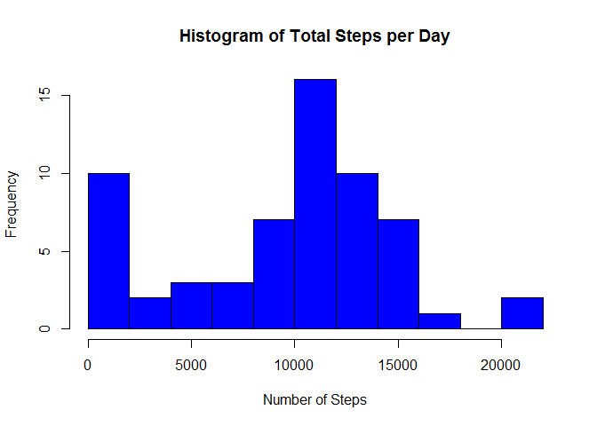

```r
        hist(sum_Data, col = "blue", main = "Histogram of Total Steps per Day",
                xlab = "Number of Steps", breaks = 10)
```

3. Calculate Mean and Median of the daily total steps

```r
        meanData <- as.integer(mean(sum_Data, na.rm = TRUE))
        medianData <- as.integer(median(sum_Data, na.rm = TRUE))
```

- The mean of the total number of steps taken per day is: **9354**
- The median of the total number of steps taken per day is: **10395**

## What is the average daily activity pattern?

1. Create a plot of the average number of steps taken during each interval

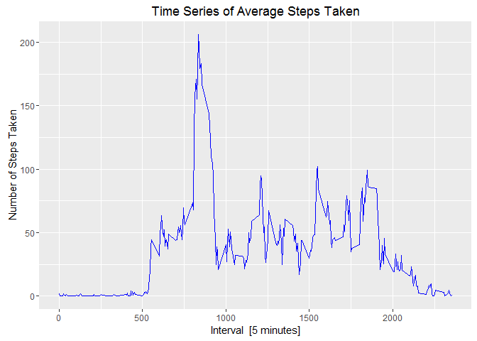

```r
        g <- ggplot( data = interval_Data, aes( Interval, Average_Steps) )
        g + geom_line(colour = "blue") + labs(title = "Time Series of Average Steps Taken") +
        labs(x = "Interval  [5 minutes]", y = "Number of Steps Taken")
```

2. Find the interval with the maximum average value

```r
        maxValue <- max(interval_Data$Average_Steps, na.rm = TRUE)
        maxInterval <- interval_Data$Interval[interval_Data$Average_Steps==maxValue]
```

- The interval with the maxium value is interval number: **835**

## Imputing missing values

1. Calculate total number of missing values “Na’s” in the data set using “is.na”

```r
        missing <- sum(is.na(myData))
```

- The total number of missing values in the data is: **2304**
2. Replace Na’s with interval average from the data set “interval_Data”, by creating a new data set named “completeData” then find the Na’s and put them in a list named “whereNA”

```r
        completeData <- myData
        whereNA <- is.na(completeData$steps)

for(i in 1:length(whereNA)){
        if(whereNA[i] == TRUE){
                myInterval <- completeData$interval[i]
                myValue <- interval_Data$Average_Steps[interval_Data$Interval==myInterval]
                completeData$steps[i] <- myValue
                }
}
```

3. Create data set named “newSum_Data” representing the total steps recorded each day using “tapply”

```r
        newSum_Data <- tapply(completeData$steps, completeData$date, sum)
```

4. Inspect the data set by making a Histogram to show the distribution of the total steps each day and calculate Mean and Median of the daily total steps

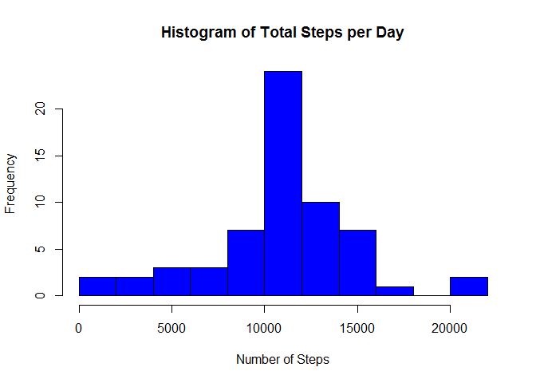

```r
        hist(newSum_Data, col = "blue", main = "Histogram of Total Steps per Day",
             xlab = "Number of Steps", breaks = 10)
```

```r
        new_meanData <- as.integer(mean(newSum_Data))
        new_medianData <- as.integer(median(newSum_Data))
```

- The mean of the total number of steps taken per day is: **10766**
- The median of the total number of steps taken per day is: **10766**

## Are there differences in activity patterns between weekdays and weekends?

1. Determine name of weekdays using “weekdays”, Update dates by replacing date names with “Weekday” or “Weekend” andm merge updated dates into dataset and transform into data.frame

```r
        completeData$date <- as.Date.factor(completeData$date)
        which_Day <- weekdays(completeData$date)

        for(i in 1:length(which_Day)){
                if(as.character(which_Day[i])== "Saturday" | as.character(which_Day[i])== "Sunday"){
                        which_Day[i] <- "Weekend"

                }else{
                        which_Day[i] <- "Weekday"
                }
        }

        which_Day <- factor(which_Day,levels=c('Weekend', 'Weekday'))
        completeData$date <- which_Day
        dateData <- data.frame(completeData)
```

2. Create dataset of interval averages with updated date names and plot data to compare weekend and weekday interval averages

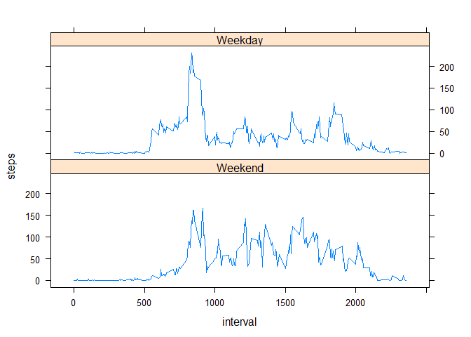

```r
        weekDay_Data= subset(dateData,date == "Weekday")
        weekEnd_Data= subset(dateData,date == "Weekend")
        week1 = aggregate(steps ~ interval + date, data = weekDay_Data, FUN = "mean" )
        week2 = aggregate(steps ~ interval + date, data = weekEnd_Data, FUN = "mean" )
        combinedData <- rbind.data.frame(week1,week2)

        xyplot(steps ~ interval | date, data = combinedData, layout = c(1,2),type = "l")
```